# Genes in high Fst Regions

[figure not shown]

## 2.4 Chr20 [21.6Mb-end] region

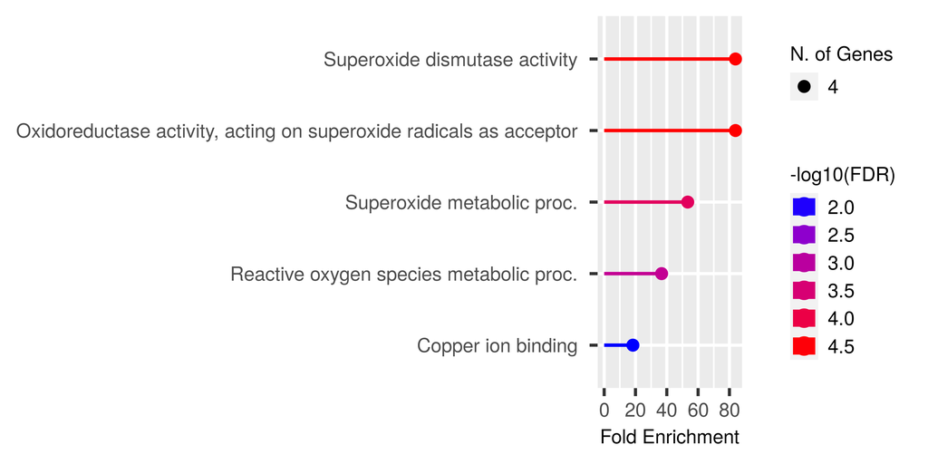

## 2.5 Chr20 [1.5-3.7Mb] inversion region

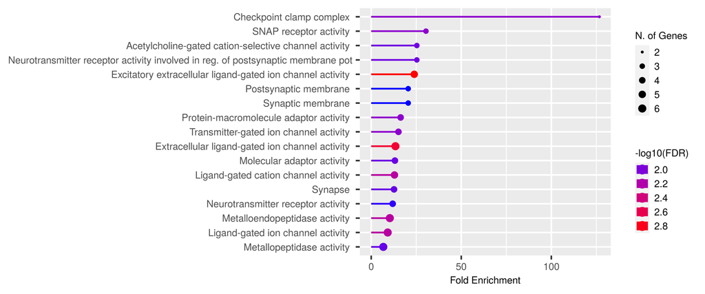

# 3 SOD in the end of Chr20

## 3.1 Look at AF in Chr20(end)

- SOD3b is between 25.6 - 26.1Mb
- Each point is a mean AF over 10,000 bp window with 5000 bp steps

```r
groups<-c("Group1","Group2","Group3")
c20af<-data.frame()
for(i in 1:3){
    df<-read.table(paste0("../Data/new_vcf/PWSonly/PWSonly_chr20_",groups[i],"_maf01_freq.frq"),stringsAsFactors = FALSE,header = FALSE, skip=1, col.names = c("chr","pos","n_allele","n_sample","MajorAF","MAF"))
    df$maf<-as.numeric(substr(df$MAF, 3,10))
    df$Maj<-as.numeric(substr(df$MajorAF, 3,10))
    df$Group<-groups[i]
    c20af<-rbind(c20af, df)
}

#Calcualte the mean over 10k window size
library(windowscanr)

Fq<-data.frame()
for(i in 1:3){
    df<-read.table(paste0("../Data/new_vcf/PWSonly/PWSonly_chr20_",groups[i],"_maf01_freq.frq"),stringsAsFactors = FALSE,header = FALSE, skip=1, col.names = c("chr","pos","n_allele","n_sample","MajorAF","MAF"))
    df$maf<-as.numeric(substr(df$MAF, 3,10))
    df$Maj<-as.numeric(substr(df$MajorAF, 3,10))
    freqs_win <- winScan(x = df, position = "pos", values = "maf", win_size = 10000, win_step = 5000, funs = "mean")
    freqs_win <- na.omit(freqs_win)
    freqs_win$Group<-groups[i]
    Fq<-rbind(Fq,freqs_win)
}

write.csv(Fq,"../Output/PCA/genes/PWSonly_chr20_af_10kwindow.csv")
#Fq<-read.csv("../Output/PCA/genes/PWSonly_chr20_af_10kwindow.csv", row.names = 1)

ggplot(Fq[Fq$win_start>=25000000&Fq$win_end<=27000000,], aes(x=win_mid, y=maf_mean, color=Group))+
    geom_line(size=0.3, alpha=0.9)+
    theme_minimal()+ scale_color_manual(values=cols)+
    ylab("MAF")+xlab('')+theme(legend.title = element_blank())
ggsave("../Output/PCA/genes/PWS_ch20_sod_AF_lineplot.png",width = 7, height = 4, dpi=300)

# Plot the windowed averaged frequenceis
ggplot(Fq[Fq$win_start>=25000000&Fq$win_end<=27000000,], aes(x=win_mid, y=maf_mean, color=Group))+
    geom_point(size=0.7, alpha=0.4)+
    geom_smooth(span = 0.1,se = FALSE, size=0.5)+
    #geom_line()+
    theme_minimal()+
    scale_color_manual(values=cols)+
    ylab("MAF")+xlab('')+theme(legend.title = element_blank())
ggsave("../Output/PCA/genes/PWS_ch20_sod_AF.png",width = 7, height = 4, dpi=300)
```

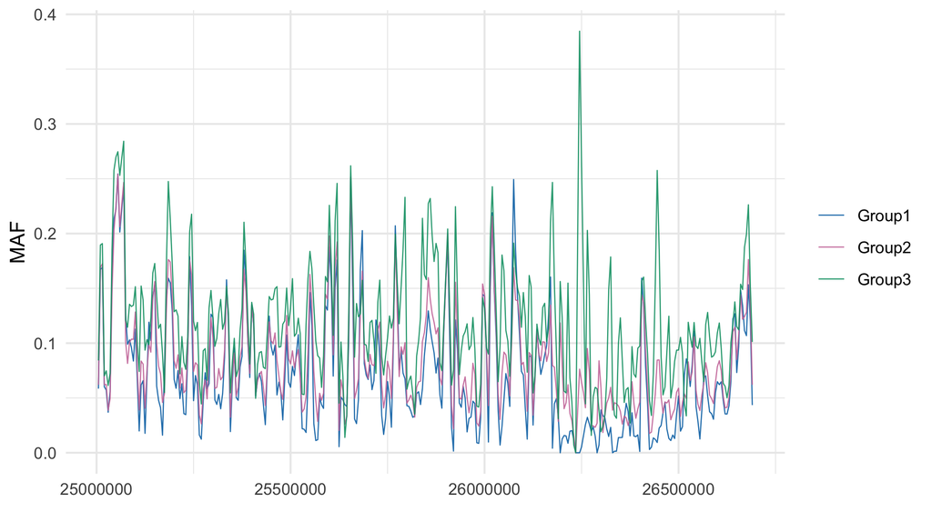

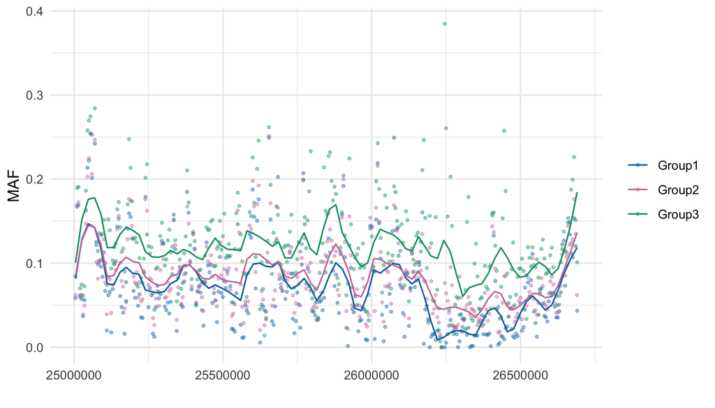

## 3.2 Focus on 26.2-26.5Mb

- the area with a high allele freq difference
- Plot the actual AF at each loci (not the window average)

```r
## Plot the actual allele frequencies
ggplot(c20af[c20af$pos>=26200000&c20af$pos<=26500000,], aes(x=pos, y=maf, color=Group))+
    geom_point(size=0.5, alpha=0.8)+
    theme_minimal()+
    scale_color_manual(values=cols)+
    ylab("MAF")+xlab('')+theme(legend.title = element_blank())
```

[output not shown]

## 3.3 Difference in Allele Freq. between Group1 and 3

```r
# Find the large allele freq differences between Group1 vs. Group3

diff<-c20af[c20af$Group=="Group1", c("chr","pos","maf")]
diff$diff<-c20af$maf[c20af$Group=="Group3"]-c20af$maf[c20af$Group=="Group1"]

ggplot(diff[abs(diff$diff)>0.5,], aes(x=pos, y=diff))+
    geom_point(size=0.5, alpha=0.8, color=blu)+
    theme_bw()+
    scale_color_manual(values=cols)+
    scale_x_continuous(labels = scales::comma)+
    ylab("AF difference")+xlab('')+theme(legend.title = element_blank())
ggsave("../Output/PCA/genes/PWSonly_chr20_bigDiffAFsites_Group3-Group1.png", width = 6, height = 4, dpi=300)
```

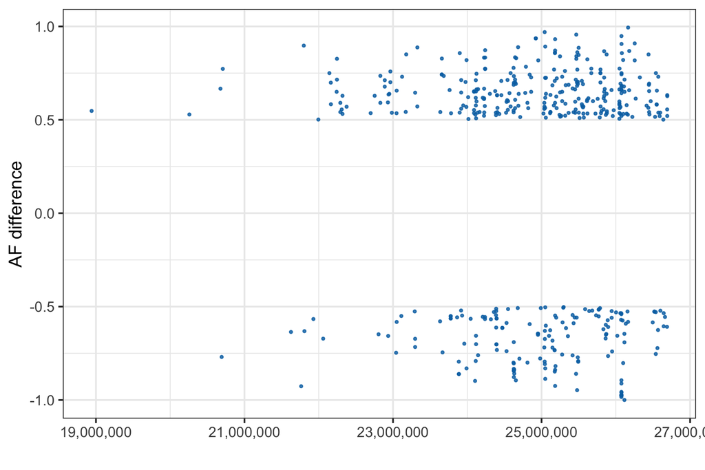

Differences are aggregated in 24Mb - 26.5Mb

## 3.4 Genes in the region:

```r
df<-read.table(paste0("../Output/PCA/genes/PWS_chr20_region_annotation"), header = F)
annotations<-data.frame()
    for (j in 1: nrow(df)){
        anns<-unlist(strsplit(df$V4[j], "\\|"))
        anns<-anns[c(2,3,4,5,8,17,18,19,20,23)]
        annotations<-rbind(annotations, anns)
    }
annotations<-cbind(df[,1:2], annotations)
colnames(annotations)<-c("chr", "pos", "Annotation","Putative_impact","Gene_name", "Gene_ID", "Transcript_biotype","Annotation2","Putative_impact2","Gene_name2", "Gene_ID2", "Transcript_biotype2")


ano<-annotations[!(duplicated(annotations[,3:6])),]
focus<-ano[ano$pos>=26425000& ano$pos<=26490000,]
write.csv(focus, "../Output/PCA/genes/Chr20_genes_in_26.4-26.6M.csv")
library(knitr)
kable(focus, caption = "Genes in the focal region")
```

[output not shown]

# 4 Find genes in high Fst regions between years in PWS

## 4.1 From the Null model

```r
outliers<-read.csv("../Output/Fst/Fst_nullshuffling_outliers_PWS.csv", row.names = 1)
#create a bed files
sink("../Output/Fst/Fst_outlier_chr25_region.bed")
cat("track type=bedGraph \n")
cat(paste0("chr19\t", outliers$midPos[outliers$CHROM=="chr19"]-25000, "\t", outliers$midPos[outliers$CHROM=="chr19"]+25000 ,"\n"))
cat(paste0("chr25\t", 805000-25000,"\t",845000+250,"\n"))
sink(NULL)
```

```bash
cd ~/Projects/PacHerring/
vcftools --gzvcf Data/new_vcf/PWSonly/PWSonly_NS0.5_maf01.vcf.gz --bed Output/Fst/Fst_outlier_chr25_region.bed --out Output/Fst/Fst_outlier_chr25_region --recode --keep-INFO-all

#Run snpEff in its directory
cd ~/projects/snpEff/
java -Xmx8g -jar snpEff.jar Ch_v2.0.2.99 ~/Projects/PacHerring/Output/Fst/Fst_outlier_chr25_region.recode.vcf -stats ~/Projects/PacHerring/Output/Fst/Fst_outlier_region.recode.vcf.html >  ~/Projects/PacHerring/Output/Fst/Fst_outlier_anno_region.recode.vcf

bcftools query -f '%CHROM %POS %INFO/AF %INFO/ANN\n' ~/Projects/PacHerring/Output/Fst/Fst_outlier_anno_region.recode.vcf > ~/Projects/PacHerring/Output/Fst/Fst_outlier_regoin_PWS_annotation
```

```r
re<-read.table("../Output/Fst/Fst_outlier_regoin_PWS_annotation")
annotations<-data.frame()
for (i in 1: nrow(re)){
    anns<-unlist(strsplit(re$V4[i], "\\|"))
    anns<-anns[c(2,3,4,8)]
    annotations<-rbind(annotations, anns)
}
re<-cbind(re[,1:3], annotations)
colnames(re)<-c("chr","pos","AF","type","impact","gene name","protein coding")

knitr::kable(re)
```

[output not shown]

- mylipa: myosin regulatory light chain interacting protein a https://zfin.org/ZDB-GENE-030131-7831#gene-ontology “Predicted to have ubiquitin-protein transferase activity. Involved in gastrulation and negative regulation of Wnt signaling pathway. Localizes to cytoplasm. Is expressed in several structures, including axis; midbrain; neural plate; polster; and retina. Orthologous to human MYLIP (myosin regulatory light chain interacting protein).” Expresssed upto juveniles